# R Notebook

Week 11 day 2 Logistic regression lab

# MVP

You’re given sample data for the customers of a telecomms company, and asked to use the data to build a classifier to predict which customers are likely to ‘churn’ (i.e. decline to renew their service contract and move to another supplier) over the next 12 months. Your clients intend to use your classifier to send targeted offers to customers likely to churn.

The sample data given in file telecomms_churn.xlsx contains a number of columns, including a Churn column stating whether each customer churned during the previous 12 months.

```r
# loading in libraries
library(tidyverse)
library(GGally)
library(janitor)
library(modelr)
library(broom)
library(pROC)
library(caret)
library(readxl)
```

# 1.

Read in the telecomms_churn.xlsx dataset, do initial data tidying and then explore its contents (try the readxl ppackage). Examine the relationships between the churn variable and other possible predictor variables, looking for significant relationships.

```r
# reading in data
telecomms <- read_xlsx("data/telecomms_churn.xlsx")

# initial overview
head(telecomms)
```

| customerID | gender | SeniorCitizen | Partner | Dependents | tenure | PhoneService | InternetService | Contract | MonthlyCharges | TotalCharges | Churn |
| --- | --- | --- | --- | --- | --- | --- | --- | --- | --- | --- | --- |
| 7590-VHVEG | Female | 0 | Yes | No | 1 | No | DSL | Month-to-month | 29.85 | 29.85 | No |
| 5575-GNVDE | Male | 0 | No | No | 34 | Yes | DSL | One year | 56.95 | 1889.50 | No |
| 3668-QPYBK | Male | 0 | No | No | 2 | Yes | DSL | Month-to-month | 53.85 | 108.15 | Yes |
| 7795-CFOCW | Male | 0 | No | No | 45 | No | DSL | One year | 42.30 | 1840.75 | No |
| 9237-HQITU | Female | 0 | No | No | 2 | Yes | Fiber optic | Month-to-month | 70.70 | 151.65 | Yes |
| 9305-CDSKC | Female | 0 | No | No | 8 | Yes | Fiber optic | Month-to-month | 99.65 | 820.50 | Yes |

```r
summary(telecomms)
```

```
  customerID           gender          SeniorCitizen      Partner           Dependents            tenure      PhoneService       InternetService
 Length:7043        Length:7043        Min.   :0.0000   Length:7043        Length:7043        Min.   : 0.00   Length:7043        Length:7043
 Class :character   Class :character   1st Qu.:0.0000   Class :character   Class :character   1st Qu.: 9.00   Class :character   Class :character
 Mode  :character   Mode  :character   Median :0.0000   Mode  :character   Mode  :character   Median :29.00   Mode  :character   Mode  :character
                                       Mean   :0.1621                                         Mean   :32.37
                                       3rd Qu.:0.0000                                         3rd Qu.:55.00
                                       Max.   :1.0000                                         Max.   :72.00

   Contract         MonthlyCharges    TotalCharges       Churn
 Length:7043        Min.   : 18.25   Min.   :  18.8   Length:7043
 Class :character   1st Qu.: 35.50   1st Qu.: 401.4   Class :character
 Mode  :character   Median : 70.35   Median :1397.5   Mode  :character
                    Mean   : 64.76   Mean   :2283.3
                    3rd Qu.: 89.85   3rd Qu.:3794.7
                    Max.   :118.75   Max.   :8684.8
                                     NA's   :11
```

```r
# the column TotalCharges has 11 NA's.
```

```r
# initial data tidying
telecomms_clean <- clean_names(telecomms)

# customer_id isn't needed, so that can be dropped

telecomms_clean <- telecomms_clean %>%
  select(-customer_id)
```

[output not shown]

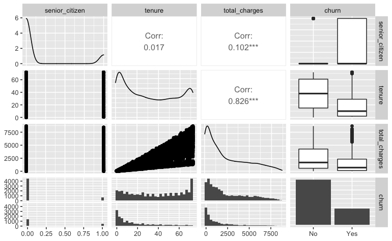

```r
# examining relationships

# the following could be significant, I will look closer:
# tenure, total_charge, senior citizen
telecomms_clean %>%
  select(c("senior_citizen", "tenure", "total_charges", "churn")) %>%
  ggpairs()
```

[output not shown]

[output cut: 45 more lines]

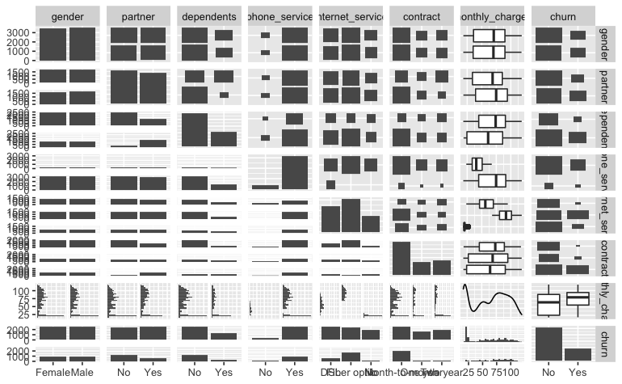

```r
# checking the ones I didn't look at
telecomms_clean %>%
  select(-c("senior_citizen", "tenure", "total_charges")) %>%
  ggpairs()
```

#2. Convert all character columns to factor columns (hint consider mutate_if() for this). Convert senior_citizen to a meaningful factor column as well.

```r
telecomms_clean <- telecomms_clean %>%
  mutate(gender = as.factor(gender),
         partner = as.factor(partner),
         dependents = as.factor(dependents),
         phone_service = as.factor(phone_service),
         internet_service = as.factor(internet_service),
         contract = as.factor(contract),
         churn = as.factor(churn),
         senior_citizen = as.factor(if_else(senior_citizen == 1, "Yes", "No")))
```

#3. Let’s perform logistic regression using the churn column as the binary dependent variable. Create three separate single predictor logistic regression models choosing from amongst the promising predictor columns you found in your analysis above. Try to have at least one continuous predictor, and at least one categorical predictor. Check that the coefficient of the single predictor in each model is statistically significant.

[output not shown]

```r
# building the second model using senior_citizen (categorical)

telecomms_model_2<- glm(churn ~ senior_citizen,
                        data = telecomms_clean,
                        family = binomial(link = 'logit'))
telecomms_model_2
```

```
Call:  glm(formula = churn ~ senior_citizen, family = binomial(link = "logit"),
    data = telecomms_clean)

Coefficients:
      (Intercept)  senior_citizenYes
          -1.1744             0.8385

Degrees of Freedom: 7042 Total (i.e. Null);  7041 Residual
Null Deviance:      8150
Residual Deviance: 8001     AIC: 8005
```

```r
telecomms_2_with_pred <- telecomms_clean %>%
  add_predictions(telecomms_model_2, type = "response")

head(telecomms_2_with_pred)
```

| gender | senior_citizen | partner | dependents | tenure | phone_service | internet_service | contract | monthly_charges | total_charges | churn | pred |
| --- | --- | --- | --- | --- | --- | --- | --- | --- | --- | --- | --- |
| Female | No | Yes | No | 1 | No | DSL | Month-to-month | 29.85 | 29.85 | No | 0.2360617 |
| Male | No | No | No | 34 | Yes | DSL | One year | 56.95 | 1889.50 | No | 0.2360617 |
| Male | No | No | No | 2 | Yes | DSL | Month-to-month | 53.85 | 108.15 | Yes | 0.2360617 |
| Male | No | No | No | 45 | No | DSL | One year | 42.30 | 1840.75 | No | 0.2360617 |
| Female | No | No | No | 2 | Yes | Fiber optic | Month-to-month | 70.70 | 151.65 | Yes | 0.2360617 |
| Female | No | No | No | 8 | Yes | Fiber optic | Month-to-month | 99.65 | 820.50 | Yes | 0.2360617 |

```r
summary(telecomms_model_2)
```

```
Call:
glm(formula = churn ~ senior_citizen, family = binomial(link = "logit"),
    data = telecomms_clean)

Deviance Residuals:
    Min       1Q   Median       3Q      Max
-1.0385  -0.7339  -0.7339   1.3230   1.6992

Coefficients:
                  Estimate Std. Error z value Pr(>|z|)
(Intercept)       -1.17439    0.03065  -38.31   <2e-16 ***
senior_citizenYes  0.83852    0.06739   12.44   <2e-16 ***
---
Signif. codes:  0 ‘***’ 0.001 ‘**’ 0.01 ‘*’ 0.05 ‘.’ 0.1 ‘ ’ 1

(Dispersion parameter for binomial family taken to be 1)

    Null deviance: 8150.1  on 7042  degrees of freedom
Residual deviance: 8001.2  on 7041  degrees of freedom
AIC: 8005.2

Number of Fisher Scoring iterations: 4
```

```r
# the p value is less than 0.05, therefore stat sig
```

```r
# building the third model using total_charges (continuous)

telecomms_model_3<- glm(churn ~ total_charges,
                        data = telecomms_clean,
                        family = binomial(link = 'logit'))
telecomms_model_3
```

```
Call:  glm(formula = churn ~ total_charges, family = binomial(link = "logit"),
    data = telecomms_clean)

Coefficients:
  (Intercept)  total_charges
   -0.5448207     -0.0002362

Degrees of Freedom: 7031 Total (i.e. Null);  7030 Residual
  (11 observations deleted due to missingness)
Null Deviance:      8143
Residual Deviance: 7834     AIC: 7838
```

```r
telecomms_3_with_pred <- telecomms_clean %>%
  add_predictions(telecomms_model_3, type = "response")

head(telecomms_3_with_pred)
```

| gender | senior_citizen | partner | dependents | tenure | phone_service | internet_service | contract | monthly_charges | total_charges | churn | pred |
| --- | --- | --- | --- | --- | --- | --- | --- | --- | --- | --- | --- |
| Female | No | Yes | No | 1 | No | DSL | Month-to-month | 29.85 | 29.85 | No | 0.3654300 |
| Male | No | No | No | 34 | Yes | DSL | One year | 56.95 | 1889.50 | No | 0.2706726 |
| Male | No | No | No | 2 | Yes | DSL | Month-to-month | 53.85 | 108.15 | Yes | 0.3611512 |
| Male | No | No | No | 45 | No | DSL | One year | 42.30 | 1840.75 | No | 0.2729521 |
| Female | No | No | No | 2 | Yes | Fiber optic | Month-to-month | 70.70 | 151.65 | Yes | 0.3587835 |
| Female | No | No | No | 8 | Yes | Fiber optic | Month-to-month | 99.65 | 820.50 | Yes | 0.3232966 |

```r
summary(telecomms_model_3)
```

```
Call:
glm(formula = churn ~ total_charges, family = binomial(link = "logit"),
    data = telecomms_clean)

Deviance Residuals:
    Min       1Q   Median       3Q      Max
-0.9547  -0.8732  -0.6752   1.4205   2.3102

Coefficients:
                Estimate Std. Error z value Pr(>|z|)
(Intercept)   -5.448e-01  3.720e-02  -14.65   <2e-16 ***
total_charges -2.362e-04  1.457e-05  -16.22   <2e-16 ***
---
Signif. codes:  0 ‘***’ 0.001 ‘**’ 0.01 ‘*’ 0.05 ‘.’ 0.1 ‘ ’ 1

(Dispersion parameter for binomial family taken to be 1)

    Null deviance: 8143.4  on 7031  degrees of freedom
Residual deviance: 7833.7  on 7030  degrees of freedom
  (11 observations deleted due to missingness)
AIC: 7837.7

Number of Fisher Scoring iterations: 4
```

```r
# the p value is less than 0.05, therefore stat sig
```

#4. So far so good! Now we’ll treat the logistic regression models as potential classifiers. Plot ROC curves for each classifier (it would be nice to put these on the same axes). Obtain AUC values for each of your classifiers and say which of them is likely to be the best classifier.

```r
# calculating the 1st ROC value
roc_1_pred <- telecomms_1_with_pred %>%
  roc(response = churn, predictor = pred)
# calculating the 2nd ROC value
roc_2_pred <- telecomms_2_with_pred %>%
  roc(response = churn, predictor = pred)
# calculating the 3rd ROC value
roc_3_pred <- telecomms_3_with_pred %>%
  roc(response = churn, predictor = pred)
```

[figure not shown]

```r
auc(roc_1_pred)
```

```
Area under the curve: 0.7399
```

```r
auc(roc_2_pred)
```

```
Area under the curve: 0.563
```

```r
auc(roc_3_pred)
```

```
Area under the curve: 0.6517
```

The AUC score is lowest for model 2, highest for model 1, therefore this is likely to be the best classifier.

#5. So far we’ve used all our data for both training and testing. Let’s perform cross validation to check how representative the AUC values you calculated above will be for unseen data

```r
# training the model
train_control <- trainControl(method = "repeatedcv",
                              number = 5,
                              repeats = 100,
                              savePredictions = TRUE,
                              classProbs = TRUE,
                              summaryFunction = twoClassSummary)
```

[output not shown]

[output not shown]

[output not shown]

#6. Take the model generating the best classifier (highest AUC value) from amongst your three and interpret the fitted coefficient of the particular predictor in that model in a meaningful way. Think in terms of odds ratio, i.e. how does changing the predictor value affect the odds that a customer will churn?